# SNF Exploration

Margaret Janiczek

8/4/2021

## Prep

Downloaded companion software SNFtool (2.3.1) from CRAN.

Simulated data as follows:

90 samples from 3 classes.

2 data matrices with “complimentary” information that both point toward the 3 classes.

First dataset: 20 cluster-related features, 50 “noisy” features. Second dataset: 10 cluster-related features, 100 “noisy” features.

```r
#simulation
#total samples = 90, total features = 70 from one data type, 110 from another.

set.seed(123)
n1 = 30 #class1
n2 = 30 #class2
n3 = 30 #class3
n = n1+n2+n3
p = 20 #cluster related features in first dataset
q = 50 #noise in first dataset
p2 = 10 #cluster related features in 2nd dataset
q2 = 100 #noise in 2nd dataset

#class1 ~ N(1.5,1), class2 ~ N(0,1), class3 ~ N(-1.5,1)

rnames = paste0("S",1:n)

#simulate features with different distributions specific to the different classes

x = NULL #empty
x1a = matrix(rnorm(n1*p, 1.5, 1), ncol=p)
x2a = matrix(rnorm(n1*p), ncol=p)
x3a = matrix(rnorm(n1*p, -1.5,1), ncol=p)
xa = rbind(x1a,x2a,x3a)
xb = matrix(rnorm(n*q), ncol=q)
x[[1]] = cbind(xa,xb)

## now simulate second data type

################
# sample 10 other informant features in a separate dataset
y1a = matrix(rnorm(n1*p2, 1.5, 1), ncol=p2)
y2a = matrix(rnorm(n1*p2), ncol=p2)
y3a = matrix(rnorm(n1*p2, -1.5,1), ncol=p2)
yb = matrix(rnorm(n*q2), ncol=q2)
ya = standardNormalization(rbind(y1a,y2a,y3a))
x[[2]] = cbind(ya, yb)

head(x[[1]][,1:10])
```

```
##           [,1]     [,2]      [,3]      [,4]      [,5]      [,6]      [,7]
## [1,] 0.9395244 1.926464 1.8796395 2.4935039 1.6176466 2.2877388 0.4366739
## [2,] 1.2698225 1.204929 0.9976765 2.0483970 0.5525254 2.2690422 2.7631852
## [3,] 3.0587083 2.395126 1.1667926 1.7387317 1.0094426 1.8322026 1.1503496
## [4,] 1.5705084 2.378133 0.4814246 0.8720939 1.2439078 0.4916234 0.6344871
## [5,] 1.6292877 2.321581 0.4282088 2.8606524 3.3438620 1.3805474 1.2637204
## [6,] 3.2150650 2.188640 1.8035286 0.8997404 0.8480501 1.2196047 1.3028241
##           [,8]      [,9]     [,10]
## [1,] 1.6192452 0.7113780 2.3450130
## [2,] 1.7436874 0.9978013 2.4625280
## [3,] 2.7324759 2.9960607 2.1843094
## [4,] 0.9839362 0.3626964 0.1047257
## [5,] 0.5074928 1.3209484 2.3496430
## [6,] 3.1756969 3.4023618 1.0534428
```

```r
####
# now what happens when we add a sparse dataset as well??


#true class labels
truelabel = c(rep(1,n1), rep(2,n2), rep(3,n3))
names(truelabel) = rnames
```

## SNF Process using SNFtool package

Calculate distance matrices (using Euclidean distance as per the paper)

```r
# calculate pairwise euclidean distances as specified by paper
dist_1 <- dist2(x[[1]], x[[1]])
dist_2 <- dist2(x[[2]], x[[2]])

head(dist_1[,1:10])
```

```
##           [,1]     [,2]     [,3]      [,4]         [,5]         [,6]     [,7]
## [1,]   0.00000 146.2916 103.9655  99.02312 1.404211e+02 1.688219e+02 125.1795
## [2,] 146.29159   0.0000 152.0022 153.71200 1.582077e+02 1.537607e+02 123.5764
## [3,] 103.96552 152.0022   0.0000 136.52761 1.220426e+02 1.082901e+02 135.4589
## [4,]  99.02312 153.7120 136.5276   0.00000 1.492202e+02 1.664323e+02 136.9064
## [5,] 140.42114 158.2077 122.0426 149.22017 5.684342e-14 1.934501e+02 125.6810
## [6,] 168.82186 153.7607 108.2901 166.43234 1.934501e+02 5.684342e-14 144.7653
##          [,8]     [,9]    [,10]
## [1,] 101.2875 130.6488 128.3733
## [2,] 140.5898 139.2355 161.2126
## [3,] 140.1077 177.9973 155.2345
## [4,] 119.9590 154.8128 176.5183
## [5,] 132.6535 128.2363 149.0441
## [6,] 156.5898 209.8598 146.9075
```

Now calculate similarity using ‘affinitymatrix’ function

Sigma is the hyperparameter, which the paper specifies is usually between 0.3-0.8.

```r
# next make similarity graph. Returns affitinity matrix representing neighborhood graph of the data points
w_1 <- affinityMatrix(dist_1, K = 10, sigma = 0.5)
w_2 <- affinityMatrix(dist_2, K = 10, sigma = 0.5)

head(w_1[,1:10])
```

```
##              [,1]         [,2]         [,3]         [,4]         [,5]
## [1,] 0.0110619454 0.0004262222 0.0012070452 0.0013176671 0.0004627613
## [2,] 0.0004262222 0.0097061187 0.0004090750 0.0003665336 0.0003540034
## [3,] 0.0012070452 0.0004090750 0.0102307640 0.0005263997 0.0008144772
## [4,] 0.0013176671 0.0003665336 0.0005263997 0.0107693960 0.0003823340
## [5,] 0.0004627613 0.0003540034 0.0008144772 0.0003823340 0.0101876746
## [6,] 0.0002397526 0.0004152811 0.0011989981 0.0002643609 0.0001523737
##              [,6]         [,7]         [,8]         [,9]        [,10]
## [1,] 0.0002397526 0.0006634473 0.0011972729 0.0006858108 0.0006161785
## [2,] 0.0004152811 0.0008016066 0.0004862401 0.0006399966 0.0003187752
## [3,] 0.0011989981 0.0005565639 0.0004576211 0.0002430248 0.0003416015
## [4,] 0.0002643609 0.0005023605 0.0007347218 0.0003908970 0.0001863482
## [5,] 0.0001523737 0.0007194676 0.0005596714 0.0007903258 0.0004012170
## [6,] 0.0097955293 0.0004655124 0.0003198794 0.0001284357 0.0004466109
```

Use function from within package to visualize heatmap with pre-specified number of clusters to see what clusters would come out from just the separate data types.

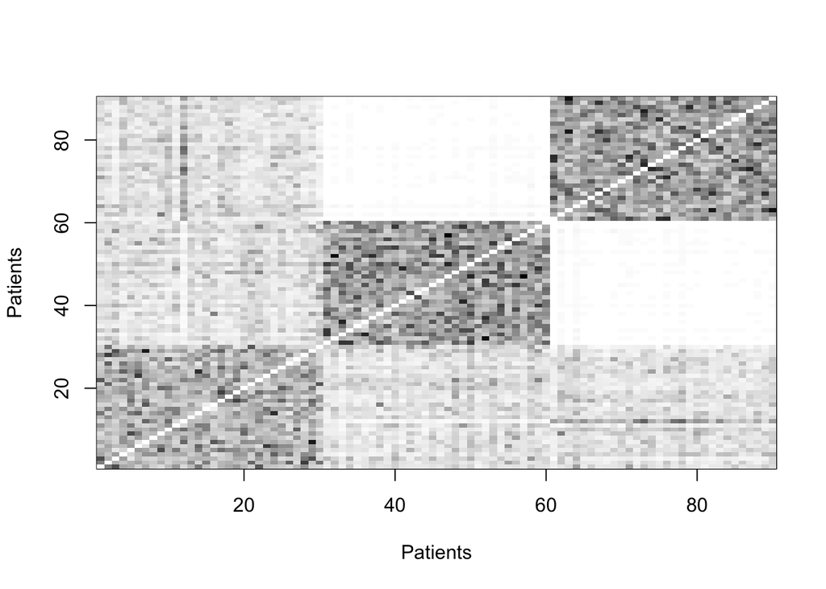

```r
displayClusters(w_1, spectralClustering(w_1, K = 3))
```

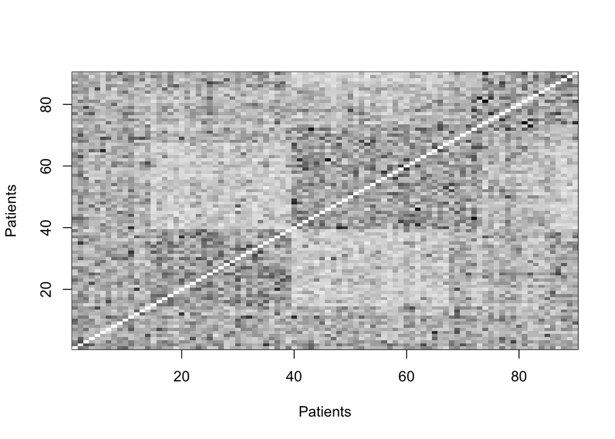

```r
displayClusters(w_2, spectralClustering(w_2, K = 3))
```

Now perform similarity network fusion to combine information from both datatypes and identify new clusters.

Below code and comments taken directly from SNFTool documentation:

```r
## First, set all the parameters:
K = 20;    # number of neighbors, usually (10~30)
alpha = 0.5;    # hyperparameter, usually (0.3~0.8)
T = 20;   # Number of Iterations, usually (10~20)

## next, we fuse all the graphs
## then the overall matrix can be computed by similarity network fusion(SNF):
W = SNF(list(w_1,w_2), K, T)
```

Visualizing the resulting matrix:

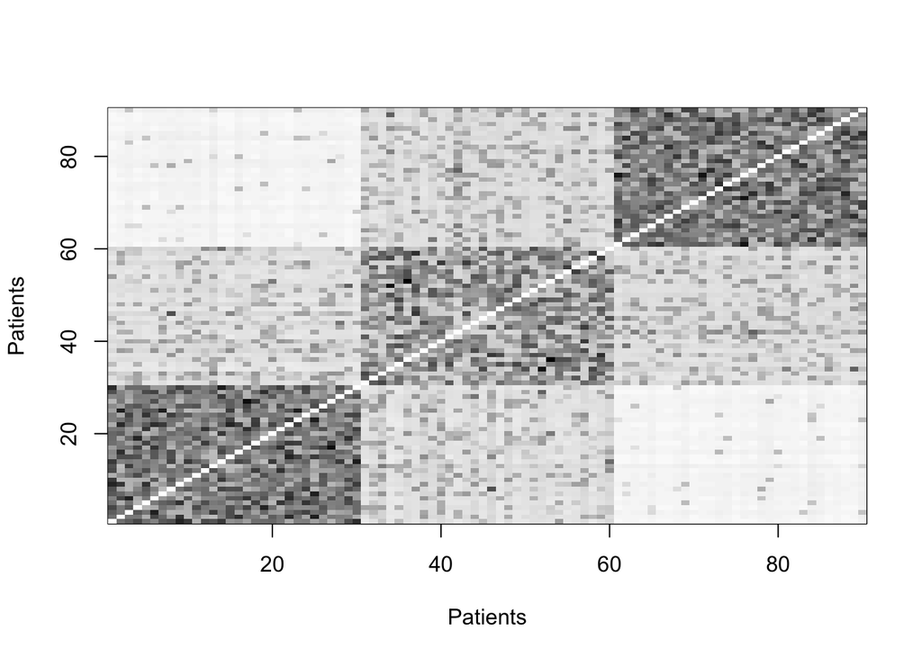

```r
displayClusters(W, group= truelabel)
```

## Looking into iteration step

Now, let’s go back and look at that iteration step.

I modified the `SNF` function to also spit out the iterations from the “key step of SNF”, (modified function is called `SNF_margie` in the code below.)

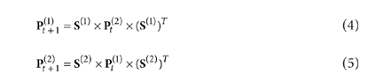

Iteration Step

```r
#modified function to also spit out the iterations as well as the final status matrix

w_margie <- SNF_margie(list(w_1, w_2), K, T)

summary(w_margie)
```

```
##                Length Class  Mode
## result         8100   -none- numeric
## knn_iterations   20   -none- list
```

Now we can go in and look at the iterations of the similarity graphs from the key step.

Iteration 1 (1st data type, 2nd data type)

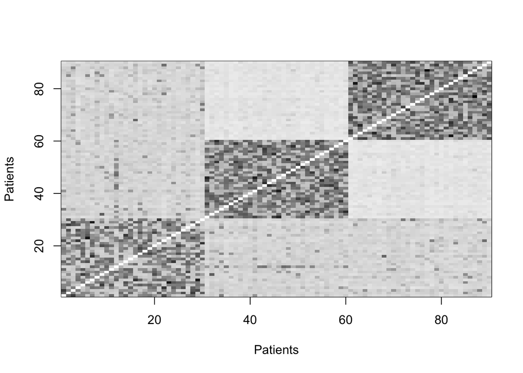

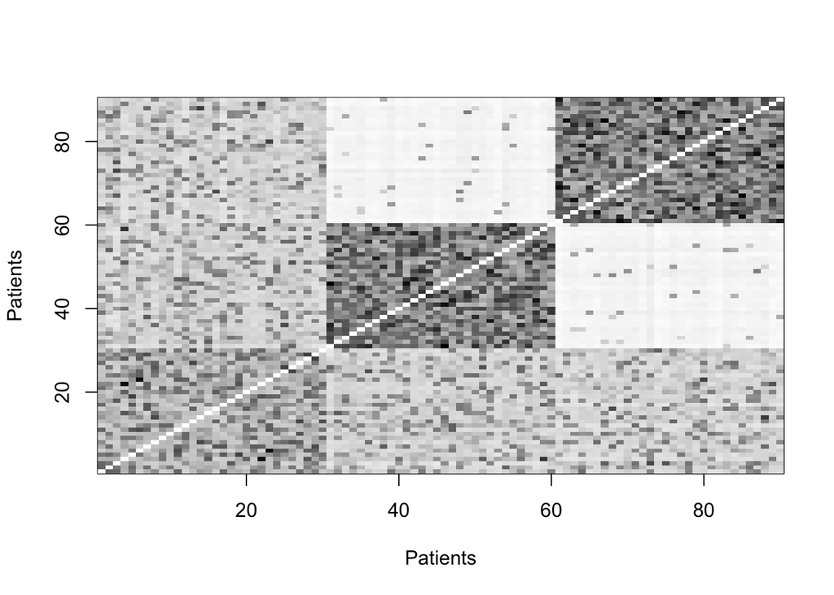

```r
displayClusters(w_margie$knn_iterations[[1]][[1]], group)
displayClusters(w_margie$knn_iterations[[1]][[2]], group)
```

Iteration 5

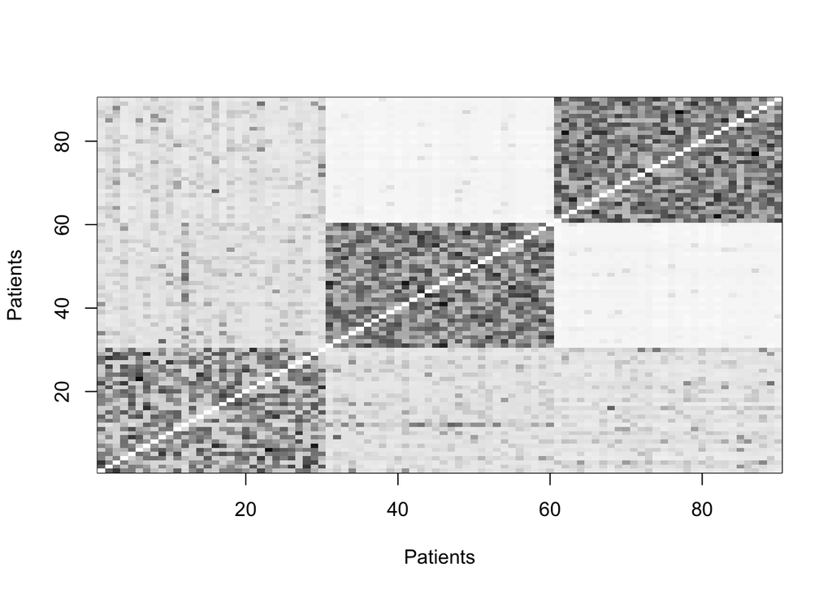

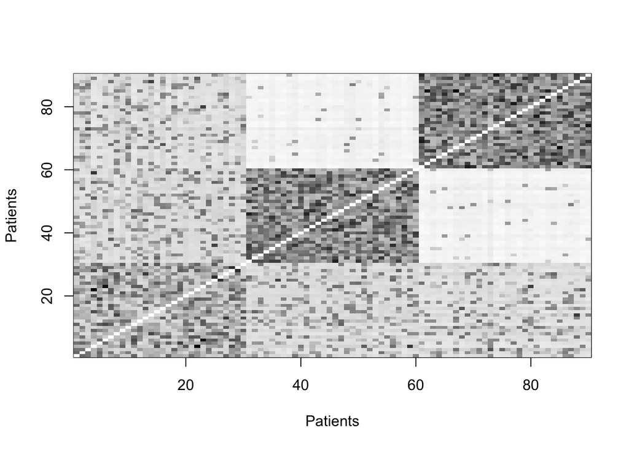

```r
displayClusters(w_margie$knn_iterations[[5]][[1]], group)
displayClusters(w_margie$knn_iterations[[5]][[2]], group)
```

Iteration 10

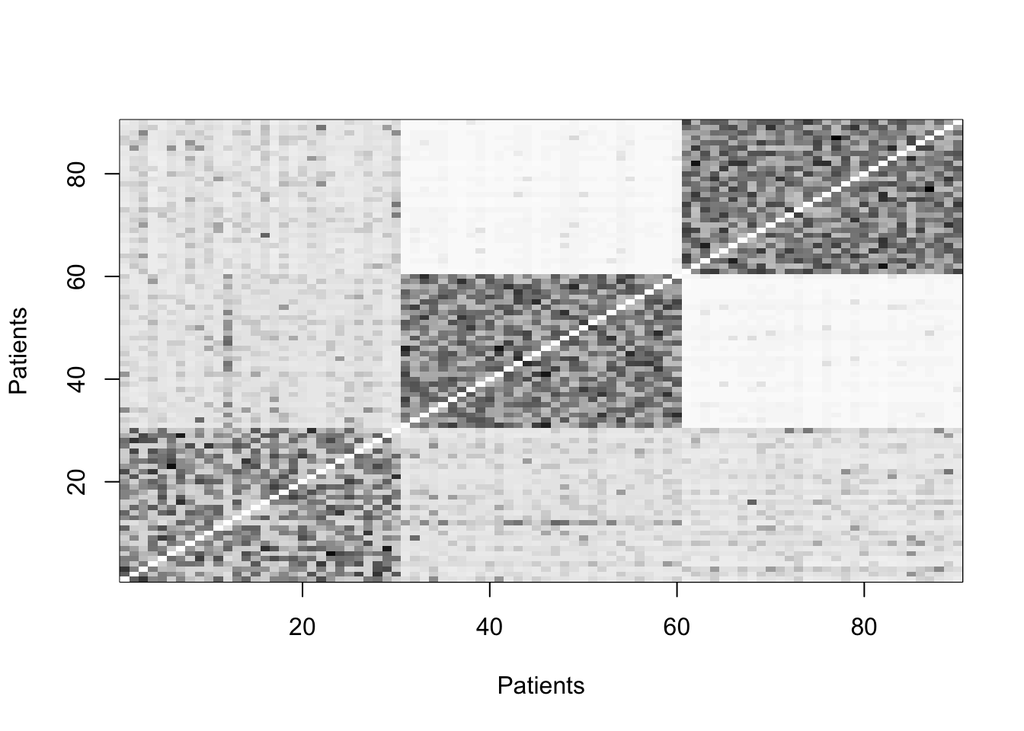

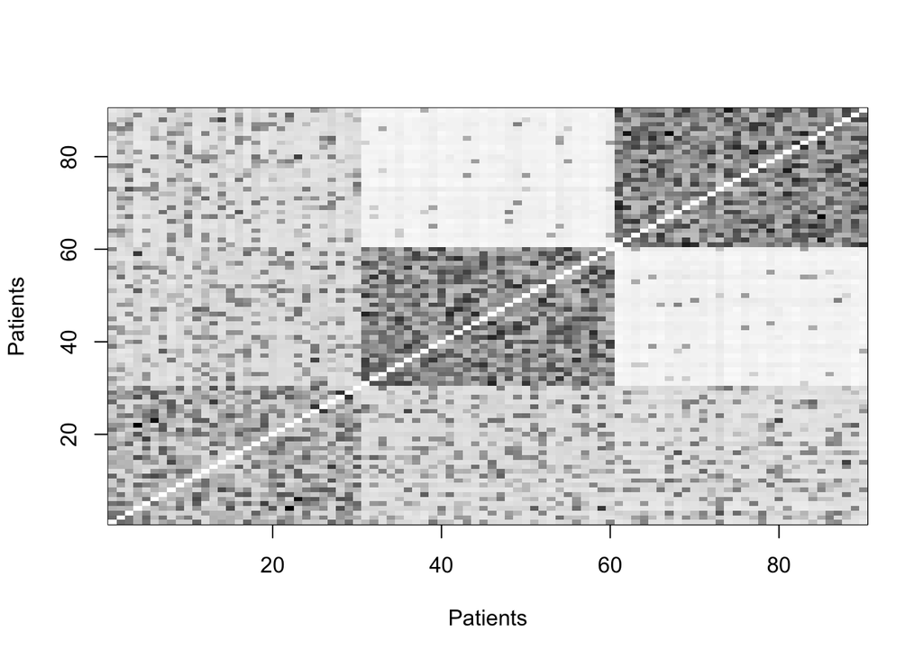

```r
displayClusters(w_margie$knn_iterations[[10]][[1]], group)
displayClusters(w_margie$knn_iterations[[10]][[2]], group)
```

Iteration 15

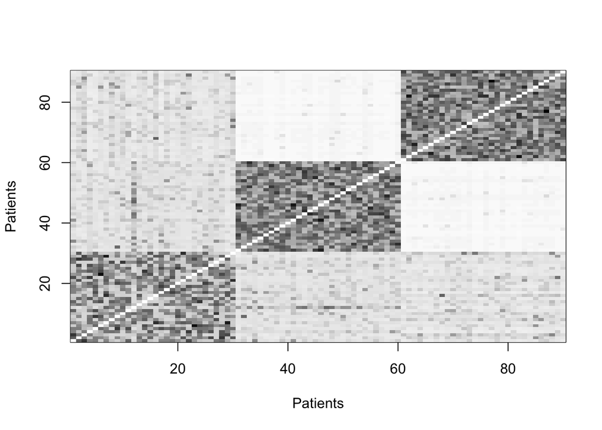

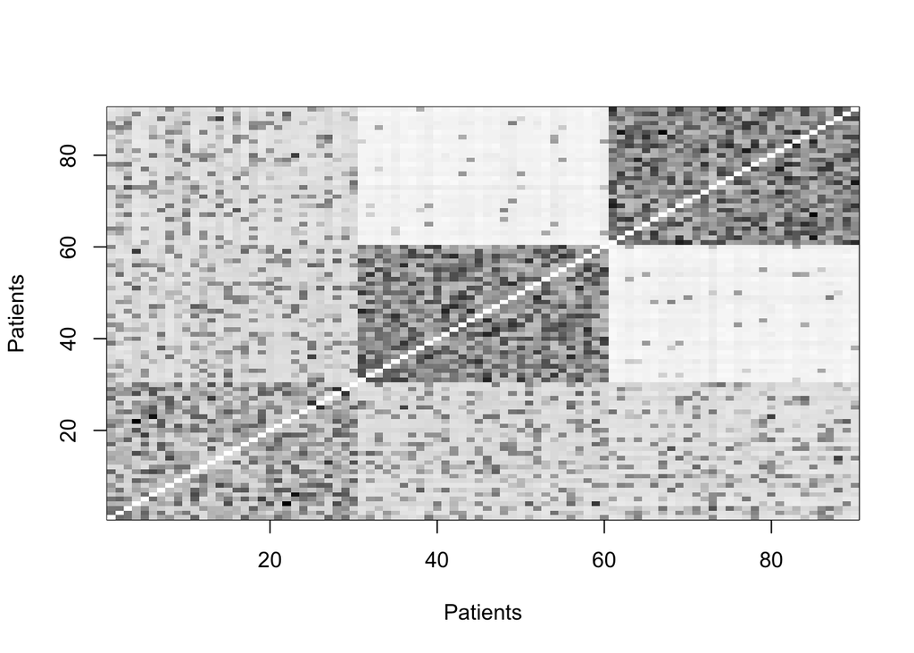

```r
displayClusters(w_margie$knn_iterations[[15]][[1]], group)
displayClusters(w_margie$knn_iterations[[15]][[2]], group)
```

Iteration 20

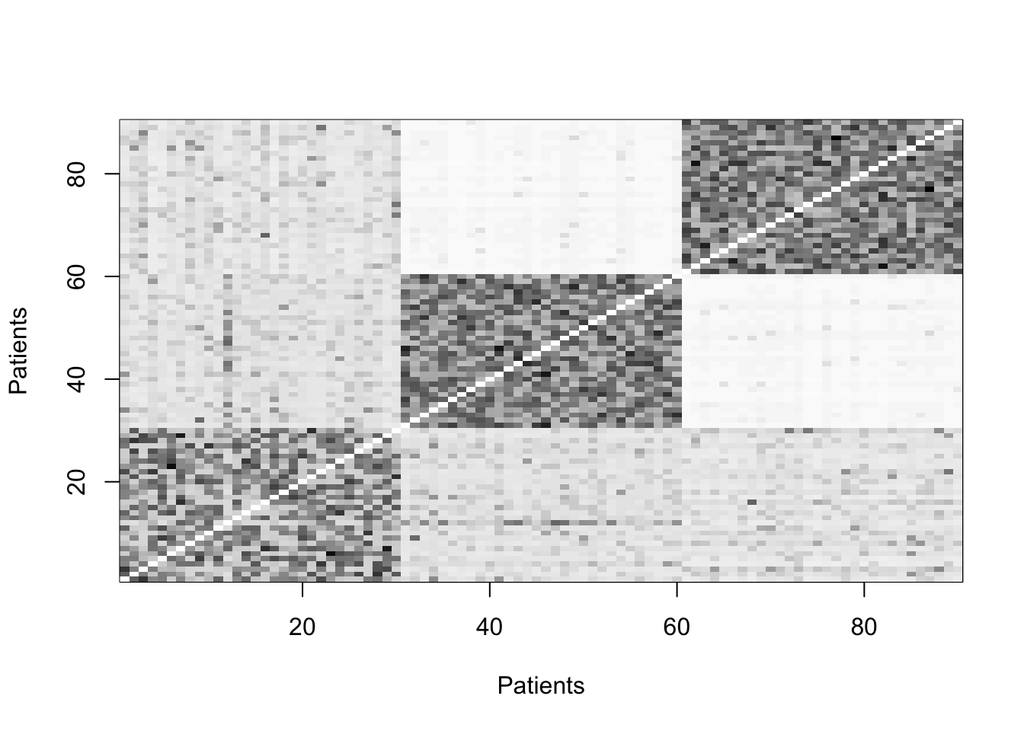

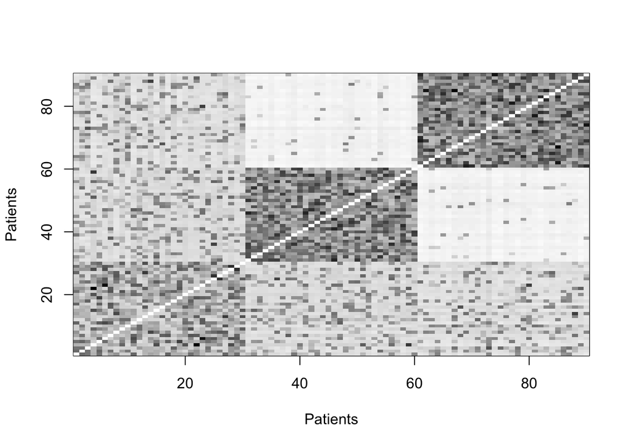

```r
displayClusters(w_margie$knn_iterations[[20]][[1]], group)
displayClusters(w_margie$knn_iterations[[20]][[2]], group)
```

## Next steps

- Try out different methods of pairwise distance
- Try using non-continuous data?
- Make one data type more sparse
- Test out effect of sigma parameter on results